# Optimal Treatment Analysis

## Outcome Variable

**Outcome Variable:** haz

## Predictor Variables

**Intervention Variable:** impfloor

**Adjustment Set:**

- arm
- sex
- W_mage
- meducyrs
- feducyrs
- hhwealth_quart
- hfoodsec
- W_mhtcm
- W_nrooms
- W_nchldlt5
- W_parity
- impsan
- safeh20
- delta_W_mage
- delta_meducyrs
- delta_feducyrs
- delta_hhwealth_quart
- delta_hfoodsec
- delta_W_mhtcm
- delta_W_nrooms
- delta_W_nchldlt5
- delta_W_parity
- delta_impsan
- delta_safeh20

## Stratifying Variables

The analysis was stratified on these variable(s):

- agecat
- studyid
- country

## Data Summary

| agecat | studyid | country | impfloor | n_cell | n |
| --- | --- | --- | --- | --- | --- |
| Birth | ki0047075b-MAL-ED | BANGLADESH | 1 | 216 | 234 |
| Birth | ki0047075b-MAL-ED | BANGLADESH | 0 | 18 | 234 |
| Birth | ki0047075b-MAL-ED | BRAZIL | 1 | 172 | 174 |
| Birth | ki0047075b-MAL-ED | BRAZIL | 0 | 2 | 174 |
| Birth | ki0047075b-MAL-ED | INDIA | 1 | 181 | 191 |
| Birth | ki0047075b-MAL-ED | INDIA | 0 | 10 | 191 |
| Birth | ki0047075b-MAL-ED | NEPAL | 1 | 66 | 164 |
| Birth | ki0047075b-MAL-ED | NEPAL | 0 | 98 | 164 |
| Birth | ki0047075b-MAL-ED | PERU | 1 | 56 | 259 |
| Birth | ki0047075b-MAL-ED | PERU | 0 | 203 | 259 |
| Birth | ki0047075b-MAL-ED | SOUTH AFRICA | 1 | 197 | 218 |
| Birth | ki0047075b-MAL-ED | SOUTH AFRICA | 0 | 21 | 218 |
| Birth | ki0047075b-MAL-ED | TANZANIA, UNITED REPUBLIC OF | 1 | 8 | 117 |
| Birth | ki0047075b-MAL-ED | TANZANIA, UNITED REPUBLIC OF | 0 | 109 | 117 |
| Birth | ki1000108-CMC-V-BCS-2002 | INDIA | 1 | 71 | 71 |
| Birth | ki1000108-CMC-V-BCS-2002 | INDIA | 0 | 0 | 71 |
| Birth | ki1000108-IRC | INDIA | 1 | 287 | 287 |
| Birth | ki1000108-IRC | INDIA | 0 | 0 | 287 |
| Birth | ki1017093-NIH-Birth | BANGLADESH | 1 | 24 | 28 |
| Birth | ki1017093-NIH-Birth | BANGLADESH | 0 | 4 | 28 |
| Birth | ki1017093c-NIH-Crypto | BANGLADESH | 1 | 21 | 27 |
| Birth | ki1017093c-NIH-Crypto | BANGLADESH | 0 | 6 | 27 |
| Birth | ki1114097-CONTENT | PERU | 1 | 2 | 2 |
| Birth | ki1114097-CONTENT | PERU | 0 | 0 | 2 |
| Birth | kiGH5241-JiVitA-3 | BANGLADESH | 1 | 1076 | 19563 |
| Birth | kiGH5241-JiVitA-3 | BANGLADESH | 0 | 18487 | 19563 |
| Birth | kiGH5241-JiVitA-4 | BANGLADESH | 1 | 71 | 822 |
| Birth | kiGH5241-JiVitA-4 | BANGLADESH | 0 | 751 | 822 |
| 6 months | ki0047075b-MAL-ED | BANGLADESH | 1 | 221 | 240 |
| 6 months | ki0047075b-MAL-ED | BANGLADESH | 0 | 19 | 240 |

[output cut: 62 more lines]

The following strata were considered:

- agecat: 24 months, studyid: ki0047075b-MAL-ED, country: BANGLADESH
- agecat: 24 months, studyid: ki0047075b-MAL-ED, country: BRAZIL
- agecat: 24 months, studyid: ki0047075b-MAL-ED, country: INDIA
- agecat: 24 months, studyid: ki0047075b-MAL-ED, country: NEPAL
- agecat: 24 months, studyid: ki0047075b-MAL-ED, country: PERU
- agecat: 24 months, studyid: ki0047075b-MAL-ED, country: SOUTH AFRICA
- agecat: 24 months, studyid: ki0047075b-MAL-ED, country: TANZANIA, UNITED REPUBLIC OF
- agecat: 24 months, studyid: ki1000108-CMC-V-BCS-2002, country: INDIA
- agecat: 24 months, studyid: ki1000108-IRC, country: INDIA
- agecat: 24 months, studyid: ki1017093-NIH-Birth, country: BANGLADESH
- agecat: 24 months, studyid: ki1017093b-PROVIDE, country: BANGLADESH
- agecat: 24 months, studyid: ki1017093c-NIH-Crypto, country: BANGLADESH
- agecat: 24 months, studyid: ki1113344-GMS-Nepal, country: NEPAL
- agecat: 24 months, studyid: ki1114097-CONTENT, country: PERU
- agecat: 24 months, studyid: kiGH5241-JiVitA-3, country: BANGLADESH
- agecat: 24 months, studyid: kiGH5241-JiVitA-4, country: BANGLADESH
- agecat: 6 months, studyid: ki0047075b-MAL-ED, country: BANGLADESH
- agecat: 6 months, studyid: ki0047075b-MAL-ED, country: BRAZIL
- agecat: 6 months, studyid: ki0047075b-MAL-ED, country: INDIA
- agecat: 6 months, studyid: ki0047075b-MAL-ED, country: NEPAL
- agecat: 6 months, studyid: ki0047075b-MAL-ED, country: PERU
- agecat: 6 months, studyid: ki0047075b-MAL-ED, country: SOUTH AFRICA
- agecat: 6 months, studyid: ki0047075b-MAL-ED, country: TANZANIA, UNITED REPUBLIC OF
- agecat: 6 months, studyid: ki1000108-CMC-V-BCS-2002, country: INDIA
- agecat: 6 months, studyid: ki1000108-IRC, country: INDIA
- agecat: 6 months, studyid: ki1017093-NIH-Birth, country: BANGLADESH
- agecat: 6 months, studyid: ki1017093b-PROVIDE, country: BANGLADESH
- agecat: 6 months, studyid: ki1017093c-NIH-Crypto, country: BANGLADESH
- agecat: 6 months, studyid: ki1113344-GMS-Nepal, country: NEPAL
- agecat: 6 months, studyid: ki1114097-CONTENT, country: PERU
- agecat: 6 months, studyid: kiGH5241-JiVitA-3, country: BANGLADESH
- agecat: 6 months, studyid: kiGH5241-JiVitA-4, country: BANGLADESH
- agecat: Birth, studyid: ki0047075b-MAL-ED, country: BANGLADESH
- agecat: Birth, studyid: ki0047075b-MAL-ED, country: BRAZIL
- agecat: Birth, studyid: ki0047075b-MAL-ED, country: INDIA
- agecat: Birth, studyid: ki0047075b-MAL-ED, country: NEPAL
- agecat: Birth, studyid: ki0047075b-MAL-ED, country: PERU
- agecat: Birth, studyid: ki0047075b-MAL-ED, country: SOUTH AFRICA
- agecat: Birth, studyid: ki0047075b-MAL-ED, country: TANZANIA, UNITED REPUBLIC OF
- agecat: Birth, studyid: ki1000108-CMC-V-BCS-2002, country: INDIA
- agecat: Birth, studyid: ki1000108-IRC, country: INDIA
- agecat: Birth, studyid: ki1017093-NIH-Birth, country: BANGLADESH
- agecat: Birth, studyid: ki1017093c-NIH-Crypto, country: BANGLADESH
- agecat: Birth, studyid: ki1114097-CONTENT, country: PERU
- agecat: Birth, studyid: kiGH5241-JiVitA-3, country: BANGLADESH
- agecat: Birth, studyid: kiGH5241-JiVitA-4, country: BANGLADESH

### Dropped Strata

- agecat: Birth, studyid: ki0047075b-MAL-ED, country: BRAZIL
- agecat: Birth, studyid: ki1000108-CMC-V-BCS-2002, country: INDIA
- agecat: Birth, studyid: ki1000108-IRC, country: INDIA
- agecat: Birth, studyid: ki1017093-NIH-Birth, country: BANGLADESH
- agecat: Birth, studyid: ki1114097-CONTENT, country: PERU
- agecat: 6 months, studyid: ki0047075b-MAL-ED, country: BRAZIL
- agecat: 6 months, studyid: ki1000108-CMC-V-BCS-2002, country: INDIA
- agecat: 6 months, studyid: ki1000108-IRC, country: INDIA
- agecat: 24 months, studyid: ki0047075b-MAL-ED, country: BRAZIL
- agecat: 24 months, studyid: ki1000108-CMC-V-BCS-2002, country: INDIA
- agecat: 24 months, studyid: ki1000108-IRC, country: INDIA

## Methods Detail

We’re interested in the causal parameters $E[Y_a]$ for all values of $a \in \mathcal{A}$. These parameters represent the mean outcome if, possibly contrary to fact, we intervened to set all units to have $A=a$. Under the randomization and positivity assumptions, these are identified by the statistical parameters $\psi_a=E_W[E_{Y|A,W}(Y|A=a,W)]$. In addition, we’re interested in the mean of $Y$, $E[Y]$ under no intervention (the observed mean). We will estimate these parameters by using SuperLearner to fit the relevant likelihood factors – $E_{Y|A,W}(Y|A=a,W)$ and $p(A=a|W)$, and then updating our likelihood fit using a joint TMLE.

For unadjusted analyses ($W=\{\}$), initial likelihoods were estimated using Lrnr_glm to estimate the simple $E(Y|A)$ and Lrnr_mean to estimate $p(A)$. For adjusted analyses, a small library containing Lrnr_glmnet, Lrnr_xgboost, and Lrnr_mean was used.

Having estimated these parameters, we will then use the delta method to estimate relative risks and attributable risks relative to a prespecified baseline level of $A$.

# Results Detail

## Results Plots

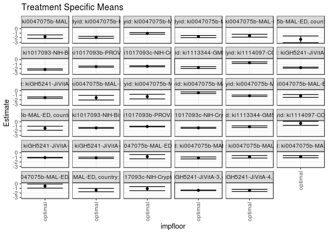

## Results Table

### Parameter: TSM

| agecat | studyid | country | intervention_level | baseline_level | estimate | ci_lower | ci_upper |
| --- | --- | --- | --- | --- | --- | --- | --- |
| Birth | ki0047075b-MAL-ED | BANGLADESH | optimal | observed | -0.8506786 | -1.3142055 | -0.3871517 |
| Birth | ki0047075b-MAL-ED | INDIA | optimal | observed | -1.1205391 | -1.3384266 | -0.9026516 |
| Birth | ki0047075b-MAL-ED | NEPAL | optimal | observed | -0.8923490 | -1.1664095 | -0.6182885 |
| Birth | ki0047075b-MAL-ED | PERU | optimal | observed | -0.8648566 | -1.0987355 | -0.6309777 |
| Birth | ki0047075b-MAL-ED | SOUTH AFRICA | optimal | observed | -0.4945683 | -0.9398854 | -0.0492513 |
| Birth | ki0047075b-MAL-ED | TANZANIA, UNITED REPUBLIC OF | optimal | observed | -1.3701052 | -1.7371752 | -1.0030352 |
| Birth | ki1017093c-NIH-Crypto | BANGLADESH | optimal | observed | -1.0540518 | -1.5031103 | -0.6049932 |
| Birth | kiGH5241-JiVitA-3 | BANGLADESH | optimal | observed | -1.4262416 | -1.4981226 | -1.3543605 |
| Birth | kiGH5241-JiVitA-4 | BANGLADESH | optimal | observed | -1.4425286 | -1.6686731 | -1.2163842 |
| 6 months | ki0047075b-MAL-ED | BANGLADESH | optimal | observed | -1.5348623 | -2.0476971 | -1.0220275 |
| 6 months | ki0047075b-MAL-ED | INDIA | optimal | observed | -1.2967348 | -1.7972531 | -0.7962165 |
| 6 months | ki0047075b-MAL-ED | NEPAL | optimal | observed | -0.4539989 | -0.6337432 | -0.2742546 |
| 6 months | ki0047075b-MAL-ED | PERU | optimal | observed | -1.1070723 | -1.2624922 | -0.9516524 |
| 6 months | ki0047075b-MAL-ED | SOUTH AFRICA | optimal | observed | -1.1447275 | -1.4593233 | -0.8301317 |
| 6 months | ki0047075b-MAL-ED | TANZANIA, UNITED REPUBLIC OF | optimal | observed | -1.4245581 | -1.8637131 | -0.9854032 |
| 6 months | ki1017093-NIH-Birth | BANGLADESH | optimal | observed | -1.3578236 | -1.4518258 | -1.2638214 |
| 6 months | ki1017093b-PROVIDE | BANGLADESH | optimal | observed | -1.0458980 | -1.1225032 | -0.9692927 |
| 6 months | ki1017093c-NIH-Crypto | BANGLADESH | optimal | observed | -1.3431792 | -1.4558225 | -1.2305358 |
| 6 months | ki1113344-GMS-Nepal | NEPAL | optimal | observed | -1.0862870 | -1.2674657 | -0.9051082 |
| 6 months | ki1114097-CONTENT | PERU | optimal | observed | -0.3595526 | -0.8031438 | 0.0840386 |
| 6 months | kiGH5241-JiVitA-3 | BANGLADESH | optimal | observed | -1.0601610 | -1.1338665 | -0.9864554 |
| 6 months | kiGH5241-JiVitA-4 | BANGLADESH | optimal | observed | -1.1034482 | -1.2533345 | -0.9535619 |
| 24 months | ki0047075b-MAL-ED | BANGLADESH | optimal | observed | -1.7758056 | -2.1701053 | -1.3815060 |
| 24 months | ki0047075b-MAL-ED | INDIA | optimal | observed | -1.9171252 | -2.1352620 | -1.6989884 |
| 24 months | ki0047075b-MAL-ED | NEPAL | optimal | observed | -1.0609149 | -1.2471523 | -0.8746774 |
| 24 months | ki0047075b-MAL-ED | PERU | optimal | observed | -1.7494064 | -1.9919085 | -1.5069044 |
| 24 months | ki0047075b-MAL-ED | SOUTH AFRICA | optimal | observed | -1.5616466 | -1.8684421 | -1.2548512 |
| 24 months | ki0047075b-MAL-ED | TANZANIA, UNITED REPUBLIC OF | optimal | observed | -2.3496735 | -3.0800942 | -1.6192528 |
| 24 months | ki1017093-NIH-Birth | BANGLADESH | optimal | observed | -2.1532930 | -2.2956873 | -2.0108988 |
| 24 months | ki1017093b-PROVIDE | BANGLADESH | optimal | observed | -1.5313615 | -1.6621026 | -1.4006204 |
| 24 months | ki1017093c-NIH-Crypto | BANGLADESH | optimal | observed | -1.4666865 | -1.5787268 | -1.3546463 |
| 24 months | ki1113344-GMS-Nepal | NEPAL | optimal | observed | -1.7320982 | -1.9378307 | -1.5263657 |
| 24 months | ki1114097-CONTENT | PERU | optimal | observed | -0.6670270 | -0.8444820 | -0.4895721 |
| 24 months | kiGH5241-JiVitA-3 | BANGLADESH | optimal | observed | -1.7485987 | -1.8612334 | -1.6359639 |
| 24 months | kiGH5241-JiVitA-4 | BANGLADESH | optimal | observed | -1.5163745 | -1.6745371 | -1.3582118 |

### Parameter: E(Y)

| agecat | studyid | country | intervention_level | baseline_level | estimate | ci_lower | ci_upper |
| --- | --- | --- | --- | --- | --- | --- | --- |
| Birth | ki0047075b-MAL-ED | BANGLADESH | observed | observed | -1.0229487 | -1.1509575 | -0.8949400 |
| Birth | ki0047075b-MAL-ED | INDIA | observed | observed | -1.0069634 | -1.1525107 | -0.8614160 |
| Birth | ki0047075b-MAL-ED | NEPAL | observed | observed | -0.6988415 | -0.8600838 | -0.5375991 |
| Birth | ki0047075b-MAL-ED | PERU | observed | observed | -0.9447876 | -1.0604945 | -0.8290808 |
| Birth | ki0047075b-MAL-ED | SOUTH AFRICA | observed | observed | -0.6917890 | -0.8248091 | -0.5587689 |
| Birth | ki0047075b-MAL-ED | TANZANIA, UNITED REPUBLIC OF | observed | observed | -0.8777778 | -1.0853531 | -0.6702024 |
| Birth | ki1017093c-NIH-Crypto | BANGLADESH | observed | observed | -1.1100000 | -1.5086894 | -0.7113106 |
| Birth | kiGH5241-JiVitA-3 | BANGLADESH | observed | observed | -1.5749762 | -1.5947643 | -1.5551882 |
| Birth | kiGH5241-JiVitA-4 | BANGLADESH | observed | observed | -1.4976642 | -1.5817349 | -1.4135935 |
| 6 months | ki0047075b-MAL-ED | BANGLADESH | observed | observed | -1.2033681 | -1.3212429 | -1.0854932 |
| 6 months | ki0047075b-MAL-ED | INDIA | observed | observed | -1.2159433 | -1.3345235 | -1.0973630 |
| 6 months | ki0047075b-MAL-ED | NEPAL | observed | observed | -0.5534934 | -0.6683107 | -0.4386762 |
| 6 months | ki0047075b-MAL-ED | PERU | observed | observed | -1.3280247 | -1.4371552 | -1.2188942 |
| 6 months | ki0047075b-MAL-ED | SOUTH AFRICA | observed | observed | -1.0548494 | -1.1845497 | -0.9251491 |
| 6 months | ki0047075b-MAL-ED | TANZANIA, UNITED REPUBLIC OF | observed | observed | -1.3613469 | -1.4843950 | -1.2382988 |
| 6 months | ki1017093-NIH-Birth | BANGLADESH | observed | observed | -1.4060639 | -1.4948910 | -1.3172368 |
| 6 months | ki1017093b-PROVIDE | BANGLADESH | observed | observed | -1.0871041 | -1.1635539 | -1.0106543 |
| 6 months | ki1017093c-NIH-Crypto | BANGLADESH | observed | observed | -1.1986783 | -1.2700937 | -1.1272630 |
| 6 months | ki1113344-GMS-Nepal | NEPAL | observed | observed | -1.3005896 | -1.3898487 | -1.2113304 |
| 6 months | ki1114097-CONTENT | PERU | observed | observed | -0.3139217 | -0.4868486 | -0.1409948 |
| 6 months | kiGH5241-JiVitA-3 | BANGLADESH | observed | observed | -1.3134597 | -1.3365976 | -1.2903219 |
| 6 months | kiGH5241-JiVitA-4 | BANGLADESH | observed | observed | -1.3440174 | -1.3812821 | -1.3067527 |
| 24 months | ki0047075b-MAL-ED | BANGLADESH | observed | observed | -1.9431132 | -2.0691678 | -1.8170586 |
| 24 months | ki0047075b-MAL-ED | INDIA | observed | observed | -1.8458150 | -1.9718703 | -1.7197596 |
| 24 months | ki0047075b-MAL-ED | NEPAL | observed | observed | -1.2618778 | -1.3846215 | -1.1391341 |
| 24 months | ki0047075b-MAL-ED | PERU | observed | observed | -1.7500995 | -1.8705474 | -1.6296516 |
| 24 months | ki0047075b-MAL-ED | SOUTH AFRICA | observed | observed | -1.6228361 | -1.7581177 | -1.4875546 |
| 24 months | ki0047075b-MAL-ED | TANZANIA, UNITED REPUBLIC OF | observed | observed | -2.6031840 | -2.7387629 | -2.4676050 |
| 24 months | ki1017093-NIH-Birth | BANGLADESH | observed | observed | -2.1856460 | -2.2886758 | -2.0826161 |
| 24 months | ki1017093b-PROVIDE | BANGLADESH | observed | observed | -1.5861179 | -1.6693668 | -1.5028689 |
| 24 months | ki1017093c-NIH-Crypto | BANGLADESH | observed | observed | -1.4295331 | -1.5127726 | -1.3462935 |
| 24 months | ki1113344-GMS-Nepal | NEPAL | observed | observed | -1.8384978 | -1.9325778 | -1.7444179 |
| 24 months | ki1114097-CONTENT | PERU | observed | observed | -0.6962195 | -0.8674103 | -0.5250287 |
| 24 months | kiGH5241-JiVitA-3 | BANGLADESH | observed | observed | -2.0124544 | -2.0401076 | -1.9848012 |
| 24 months | kiGH5241-JiVitA-4 | BANGLADESH | observed | observed | -1.7579225 | -1.7933649 | -1.7224800 |

### Parameter: PAR

| agecat | studyid | country | intervention_level | baseline_level | estimate | ci_lower | ci_upper |
| --- | --- | --- | --- | --- | --- | --- | --- |
| Birth | ki0047075b-MAL-ED | BANGLADESH | optimal | observed | -0.1722701 | -0.6182071 | 0.2736669 |
| Birth | ki0047075b-MAL-ED | INDIA | optimal | observed | 0.1135757 | -0.0576751 | 0.2848266 |
| Birth | ki0047075b-MAL-ED | NEPAL | optimal | observed | 0.1935075 | 0.0015702 | 0.3854449 |
| Birth | ki0047075b-MAL-ED | PERU | optimal | observed | -0.0799311 | -0.2641365 | 0.1042744 |
| Birth | ki0047075b-MAL-ED | SOUTH AFRICA | optimal | observed | -0.1972207 | -0.6121714 | 0.2177301 |
| Birth | ki0047075b-MAL-ED | TANZANIA, UNITED REPUBLIC OF | optimal | observed | 0.4923274 | 0.2260687 | 0.7585861 |
| Birth | ki1017093c-NIH-Crypto | BANGLADESH | optimal | observed | -0.0559482 | -0.3010548 | 0.1891583 |
| Birth | kiGH5241-JiVitA-3 | BANGLADESH | optimal | observed | -0.1487347 | -0.2197904 | -0.0776790 |
| Birth | kiGH5241-JiVitA-4 | BANGLADESH | optimal | observed | -0.0551356 | -0.2752453 | 0.1649742 |
| 6 months | ki0047075b-MAL-ED | BANGLADESH | optimal | observed | 0.3314943 | -0.1500403 | 0.8130289 |
| 6 months | ki0047075b-MAL-ED | INDIA | optimal | observed | 0.0807916 | -0.4010740 | 0.5626571 |
| 6 months | ki0047075b-MAL-ED | NEPAL | optimal | observed | -0.0994945 | -0.2255139 | 0.0265248 |
| 6 months | ki0047075b-MAL-ED | PERU | optimal | observed | -0.2209524 | -0.3438674 | -0.0980374 |
| 6 months | ki0047075b-MAL-ED | SOUTH AFRICA | optimal | observed | 0.0898781 | -0.1990109 | 0.3787670 |
| 6 months | ki0047075b-MAL-ED | TANZANIA, UNITED REPUBLIC OF | optimal | observed | 0.0632112 | -0.3687237 | 0.4951461 |
| 6 months | ki1017093-NIH-Birth | BANGLADESH | optimal | observed | -0.0482402 | -0.0800292 | -0.0164512 |
| 6 months | ki1017093b-PROVIDE | BANGLADESH | optimal | observed | -0.0412061 | -0.0687435 | -0.0136687 |
| 6 months | ki1017093c-NIH-Crypto | BANGLADESH | optimal | observed | 0.1445009 | 0.0609397 | 0.2280620 |
| 6 months | ki1113344-GMS-Nepal | NEPAL | optimal | observed | -0.2143026 | -0.3745506 | -0.0540547 |
| 6 months | ki1114097-CONTENT | PERU | optimal | observed | 0.0456309 | -0.3558615 | 0.4471233 |
| 6 months | kiGH5241-JiVitA-3 | BANGLADESH | optimal | observed | -0.2532988 | -0.3263436 | -0.1802539 |
| 6 months | kiGH5241-JiVitA-4 | BANGLADESH | optimal | observed | -0.2405692 | -0.3818176 | -0.0993209 |
| 24 months | ki0047075b-MAL-ED | BANGLADESH | optimal | observed | -0.1673076 | -0.5501501 | 0.2155349 |
| 24 months | ki0047075b-MAL-ED | INDIA | optimal | observed | 0.0713102 | -0.1078080 | 0.2504284 |
| 24 months | ki0047075b-MAL-ED | NEPAL | optimal | observed | -0.2009629 | -0.3395474 | -0.0623785 |
| 24 months | ki0047075b-MAL-ED | PERU | optimal | observed | -0.0006931 | -0.1958388 | 0.1944527 |
| 24 months | ki0047075b-MAL-ED | SOUTH AFRICA | optimal | observed | -0.0611895 | -0.3636543 | 0.2412753 |
| 24 months | ki0047075b-MAL-ED | TANZANIA, UNITED REPUBLIC OF | optimal | observed | -0.2535105 | -0.9702867 | 0.4632657 |
| 24 months | ki1017093-NIH-Birth | BANGLADESH | optimal | observed | -0.0323529 | -0.1293797 | 0.0646738 |
| 24 months | ki1017093b-PROVIDE | BANGLADESH | optimal | observed | -0.0547563 | -0.1559856 | 0.0464730 |
| 24 months | ki1017093c-NIH-Crypto | BANGLADESH | optimal | observed | 0.0371535 | -0.0323452 | 0.1066521 |
| 24 months | ki1113344-GMS-Nepal | NEPAL | optimal | observed | -0.1063996 | -0.2956442 | 0.0828450 |
| 24 months | ki1114097-CONTENT | PERU | optimal | observed | -0.0291925 | -0.0692137 | 0.0108288 |
| 24 months | kiGH5241-JiVitA-3 | BANGLADESH | optimal | observed | -0.2638557 | -0.3758334 | -0.1518781 |
| 24 months | kiGH5241-JiVitA-4 | BANGLADESH | optimal | observed | -0.2415480 | -0.3922119 | -0.0908841 |